# Fit MOSM GP to 2-band synthetic example

This notebook contains the workflow for:

- loading groundtruth 2-band (MOGP) time-series,
- fitting a multicomponent MOSM GP model,
- drawing posterior predictive samples,
- visualising the posteriors.

```r
library(here)
library(tidyr)
library(ggplot2)
library(cmdstanr)
library(posterior)
library(bayesplot)
library(readr)
library(glue)
library(jsonlite)
library(MCMCpack) # rdirichlet()
library(dplyr)

register_knitr_engine(override = FALSE)

theme_set(theme_bw())
color_scheme_set("viridis")

source(here("mogp-utils.R"))

filename_stub <- "D2-Q3-seed4458-n300-mnar0.2-noise0.5"

EXECUTE_SAMPLING <- FALSE

N_CHAINS <- 6
N_WARMUP <- 1000
N_SAMPLES <- 1000

# Function estimates the mode of a sample
estimate_mode <- function(x) {
  d <- density(x, n = 2^6)
  d$x[which.max(d$y)]
}

# Function plots histograms of draws
plot_draw_histograms <- function(draws, parameter_name) {
  draws_tidy <- draws |>
    as.data.frame() |>
    dplyr::select(.draw, starts_with( paste0(parameter_name, "[") )) |>
    pivot_longer(2:7) |>
    separate_wider_position(
      cols = name,
      width = c("p" = stringr::str_length(parameter_name), 1, "Component" = 1, 1, "Band" = 1, 1))

  if (parameter_name == "s") {
    draws_tidy <- draws_tidy |>
      rename(Component = "Band", Band = "Component") # s matrix is transposed
  }

  draws_tidy |>
    ggplot() +
    aes(x = value, fill = Band) +
    geom_histogram(mapping = aes( y = after_stat(density) ),
                   bins = 50, position = "identity", alpha = 0.5) +
    facet_grid(rows = vars(Component), scales = "free", labeller = "label_both") +
    labs(x = parameter_name)
}
```

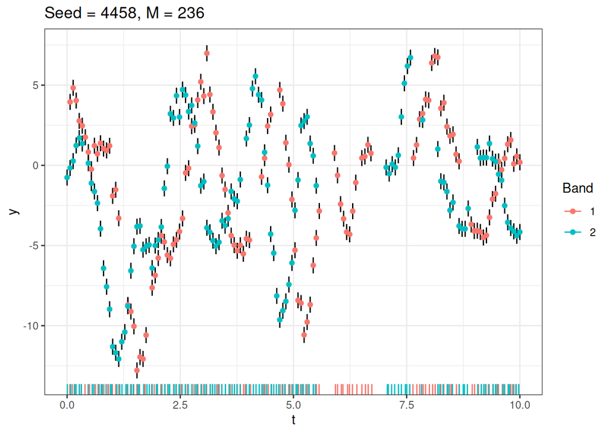

```r
input_df <- read_csv(
  here("data", glue("{filename_stub}-sim.csv")),
  col_types = "dddf",
  show_col_types = FALSE)

input_params <- read_json(
  here("data", glue("{filename_stub}-param.json")),
  simplifyVector = TRUE)

input_df |>
  ggplot() +
  aes(x = t, y = y, colour = factor(d)) +
  geom_linerange(aes(ymax = y + y_se, ymin = y - y_se), colour = "black") +
  geom_point() +
  geom_rug(sides = "b", position = "jitter") +
  labs(colour = "Band",
       title = glue("Seed = {input_params$seed}, M = {NROW(input_df)}"))
```

Notes on data:

- there is a gap in Band 2 data at around t = 6 to 7.
- the time delay between Band 1 and 2 is perceptible in the distance between peaks, i.e., approximately 0.5.
- both bands appear to have stationary mean and variance.

```r
input_params
```

```
$seed
[1] 4458

$w
     [,1] [,2]
[1,]    1    1
[2,]    1    1
[3,]    1    1

$mu
     [,1] [,2]
[1,]    1    1
[2,]    2    2
[3,]    5    6

$Sigma
     [,1] [,2]
[1,]    4    4
[2,]    4    4
[3,]    4    4

$theta
     [,1] [,2]
[1,]    0  0.5
[2,]    0  0.5
[3,]    0  0.5

$phi
     [,1] [,2]
[1,]    0    0
[2,]    0    0
[3,]    0    0
```

- All bands and components have the same weights, $w$.
- All components have the same central spectral frequency, $\mu$, across bands except for Component 3.
- Spectral widths/length scales, $\Sigma$, are the same across all bands and components.
- Time delay between bands, $\theta$, are the same across all components.
- Phase differences, $\phi$, are all zero.

# Model Fitting

```r
stan_model <- cmdstan_model(here("stan", "mosmgp-D2-Q.stan"))
```

## Sampling

```r
D <- 2
Q <- 3

band1_df <- filter(input_df, d == 1)
band1_mean <- mean(band1_df$y)
band1_sd <- sd(band1_df$y)

band2_df <- filter(input_df, d == 2)
band2_mean <- mean(band2_df$y)
band2_sd <- sd(band2_df$y)

ell_min <- diff( sort(input_df$t) ) |> median()
ell_max <- diff(range(input_df$t))
ell_loc <- log(sqrt(ell_min * ell_max)) # for log-normal prior

band1_df$y_std <- (band1_df$y - band1_mean)/band1_sd # standardised
band1_df$y_se_std <- band1_df$y_se/band1_sd

band2_df$y_std <- (band2_df$y - band2_mean)/band2_sd
band2_df$y_se_std <- band2_df$y_se/band2_sd

data_list <- list(
  Q = Q,
  N1 = length(band1_df$t),
  N2 = length(band2_df$t),
  t1 = band1_df$t,
  t2 = band2_df$t,
  y1 = band1_df$y_std,
  y2 = band2_df$y_std,
  y1_se = band1_df$y_se_std,
  y2_se = band2_df$y_se_std,
  ell_min = ell_min,
  ell_max = ell_max,
  ell_loc = ell_loc,
  ell_scale = 1,
  signal_sd_scale = 0.5, # for lognormal prior
  dir_conc = 0.8,
  mu_scale = 3 # for halfnormal priors, radians/unit time
)
```

```r
ell_min
```

```
[1] 0.06711409
```

```r
ell_max
```

```
[1] 10
```

```r
ell_loc
```

```
[1] -0.1993881
```

```r
format(start_time <- Sys.time())
```

```
[1] "2026-10-29 15:17:58"
```

```r
if (EXECUTE_SAMPLING) {
  init_fun <- function() {
    list(
      signal_sd = c(0.8, 0.8),
      s = rbind(rep(1 / Q, Q), rep(1 / Q, Q))   # array[2] simplex[Q]
      #mu1 = c(1, 2, 5) + rnorm(Q, 0, 0.5),
      #mu2 = c(1, 2, 6) + rnorm(Q, 0, 0.5)
    )
  }

  output <- stan_model$sample(
    data = data_list,
    init = init_fun,
    chains = N_CHAINS,
    parallel_chains = N_CHAINS,
    iter_warmup = N_WARMUP,
    iter_sampling = N_SAMPLES,
    refresh = 500,
    show_exceptions = FALSE,
    show_messages = TRUE
  )

  output$save_object(
    here("RDS", glue("{filename_stub}_mosmgp-D{D}-Q{Q}.RDS")))

} else {
  output <- readRDS(
    here("RDS", glue("{filename_stub}_mosmgp-D{D}-Q{Q}.RDS")))
}

format(finish_time <- Sys.time())
```

```
[1] "2026-10-29 15:17:58"
```

```r
difftime(finish_time, start_time)
```

```
Time difference of 0.02609944 secs
```

# Results

## Check convergence

Check the converge for the parameters that were sampled:

```r
sampled_vars <- c("signal_sd", "s", "mu", "ell", "theta", "phi")
all_vars <- c("w", "mu", "Sigma", "theta", "phi", "signal_sd", "s", "v", "ell")
output$summary(variables = sampled_vars, default_convergence_measures())
```

```
# A tibble: 32 × 4
   variable      rhat ess_bulk ess_tail
   <chr>        <dbl>    <dbl>    <dbl>
 1 signal_sd[1]  1.00   2800.    3213.
 2 signal_sd[2]  1.00   2184.    2448.
 3 s[1,1]        1.38     13.0     25.9
 4 s[2,1]        1.38     13.1     24.1
 5 s[1,2]        1.36     13.7     31.2
 6 s[2,2]        1.35     13.9     31.3
 7 s[1,3]        1.57     10.3     75.9
 8 s[2,3]        1.58     10.5     76.1
 9 mu[1,1]       1.03    178.     165.
10 mu[2,1]       1.05     98.7    223.
# ℹ 22 more rows
```

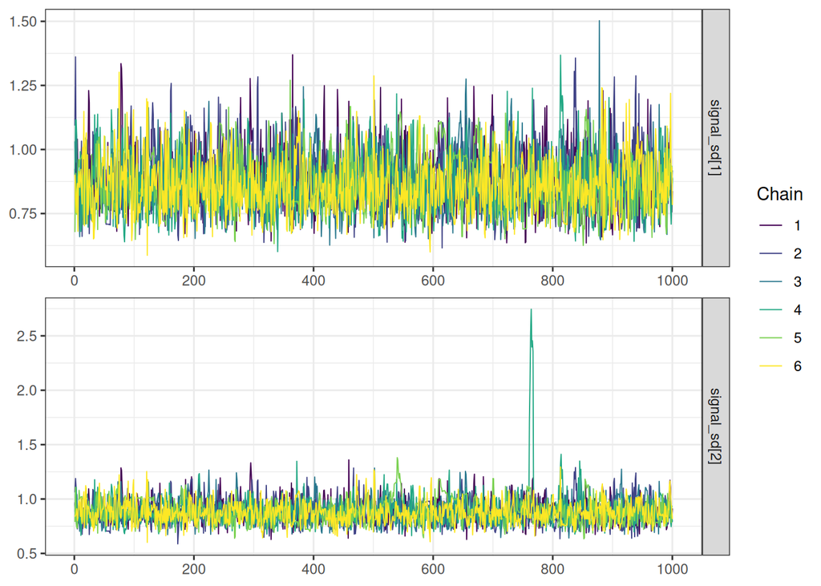

```r
mcmc_trace(output$draws(sampled_vars), pars = vars(starts_with("signal")),
           facet_args = list(nrow = 2, strip.position = "right"))
```

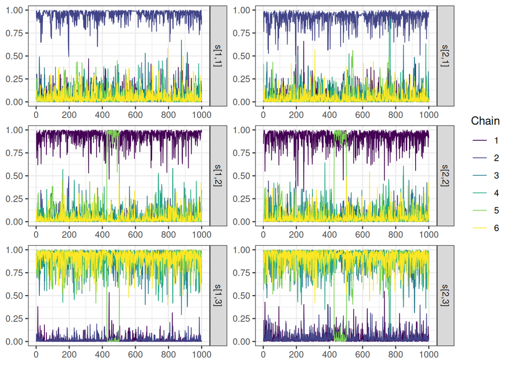

```r
mcmc_trace(output$draws(sampled_vars), pars = vars(starts_with("s[")),
           facet_args = list(nrow = 3, strip.position = "right", dir = "lt"))
```

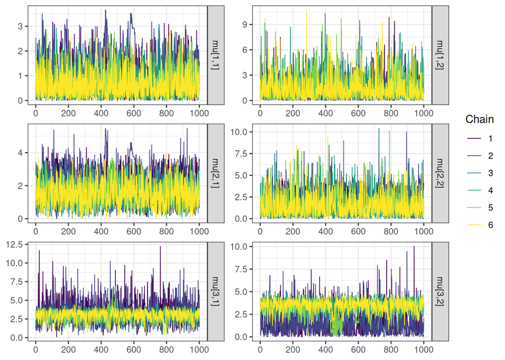

```r
mcmc_trace(output$draws(sampled_vars), pars = vars(starts_with("mu")),
           facet_args = list(ncol = 2, strip.position = "right", dir = "tl"))
```

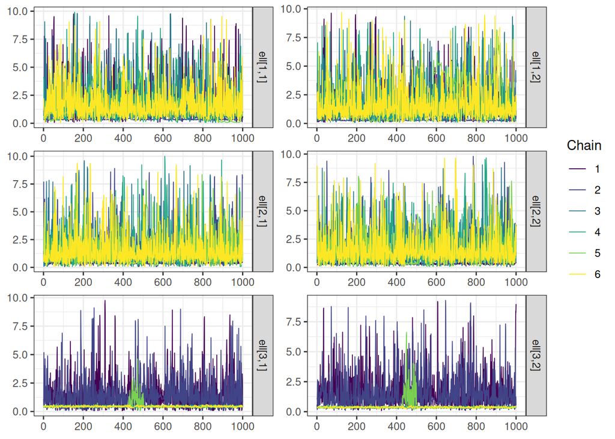

```r
mcmc_trace(output$draws(sampled_vars), pars = vars(starts_with("ell")),
           facet_args = list(ncol = 2, strip.position = "right", dir = "tl"))
```

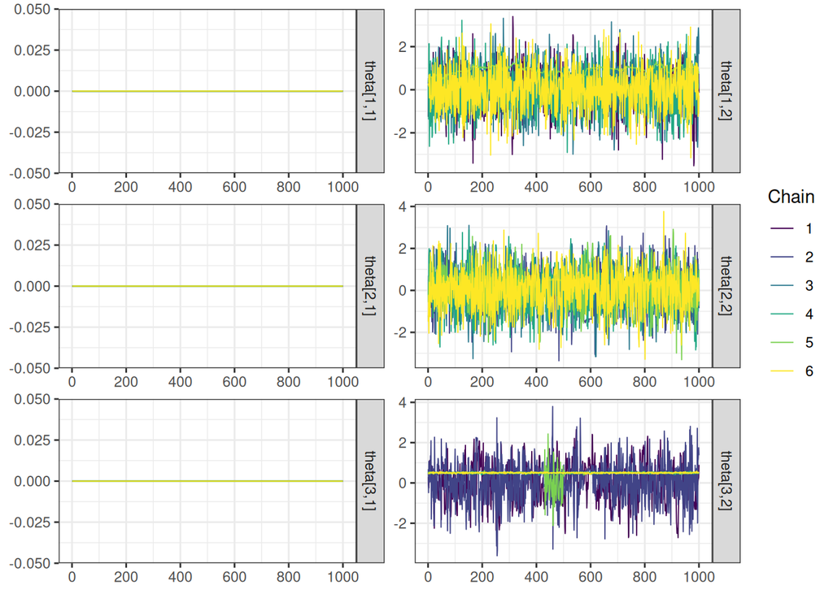

```r
mcmc_trace(output$draws(sampled_vars), pars = vars(starts_with("theta")),
           facet_args = list(ncol = 2, strip.position = "right", dir = "tl"))
```

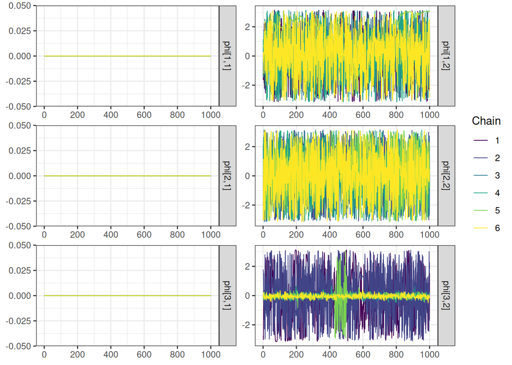

```r
mcmc_trace(output$draws(sampled_vars), pars = vars(starts_with("phi")),
           facet_args = list(ncol = 2, strip.position = "right", dir = "tl"))
```

## Valid Chains

```r
valid_chains <- c(3,4,6)

output_draws <- output$draws(variables = all_vars, format = "df") |>
  subset_draws(chain = valid_chains)
output_draws_mat <- as.matrix(output_draws)

summarise_draws(output_draws, default_convergence_measures())
```

```
# A tibble: 50 × 4
   variable  rhat ess_bulk ess_tail
   <chr>    <dbl>    <dbl>    <dbl>
 1 w[1,1]    1.00    1642.    1642.
 2 w[2,1]    1.00    1301.    1579.
 3 w[3,1]    1.00    1304.    1584.
 4 w[1,2]    1.00    1321.    1755.
 5 w[2,2]    1.00    1358.    1409.
 6 w[3,2]    1.00    1261.    1354.
 7 mu[1,1]   1.00    1679.    1541.
 8 mu[2,1]   1.00    1590.    1303.
 9 mu[3,1]   1.00     883.     928.
10 mu[1,2]   1.00    1540.    1382.
# ℹ 40 more rows
```

## Posterior Predictive Check

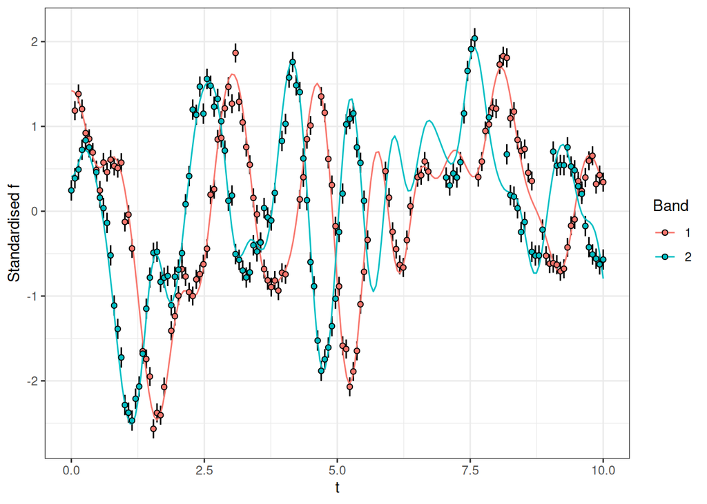

```r
n_star <- 200
ts1 <- seq(from = 0, to = 10, length.out = n_star)
ts2 <- ts1

# Draw posterior predictive samples using a particular posterior draw
post_draw <- as.data.frame(output_draws[sample.int(nrow(output_draws_mat), 1),])

pp_draw <- pred_D2_Q_draw(post_draw,
                          Q = Q,
                          t1 = band1_df$t,
                          t2 = band2_df$t,
                          y1 = band1_df$y_std,
                          y2 = band2_df$y_std,
                          y1_se = band1_df$y_se_std,
                          y2_se = band2_df$y_se_std,
                          ts1 = ts1, ts2 = ts2)

ggplot() +
  geom_linerange(data = rbind(band1_df, band2_df),
                 mapping = aes(x = t,
                               ymax = y_std + y_se_std,
                               ymin = y_std - y_se_std),
                 colour = "black") +
  geom_line(data = pp_draw, aes(x = ts, y = fs, colour = d)) +
  geom_point(data = rbind(band1_df, band2_df),
             mapping = aes(x = t, y = y_std, fill = d), shape = 21, size = 1.5) +
  labs(colour = "Band", fill = "Band", y = "Standardised f")
```

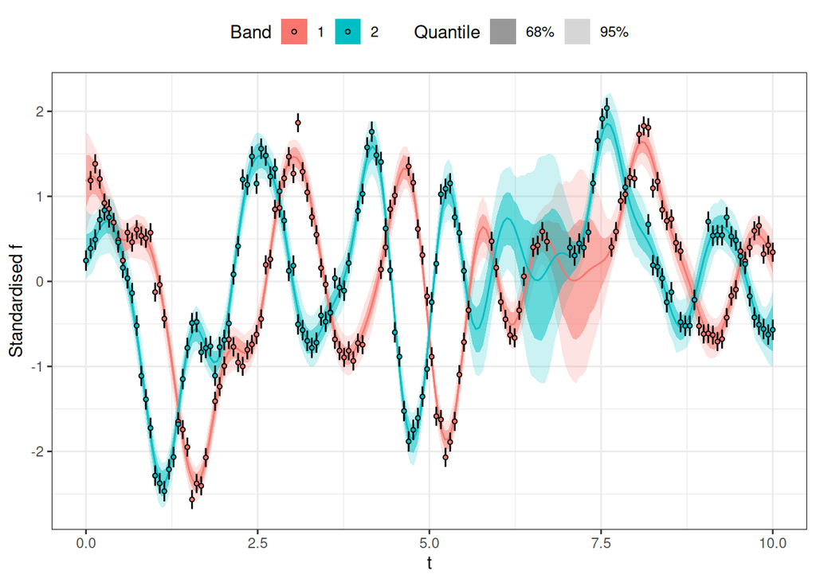

```r
pp_draws <- pred_D2_Q(draws = output_draws,
                      Q = Q,
                      t1 = band1_df$t,
                      t2 = band2_df$t,
                      y1 = band1_df$y_std,
                      y2 = band2_df$y_std,
                      y1_se = band1_df$y_se_std,
                      y2_se = band2_df$y_se_std,
                      ts1 = ts1,
                      ts2 = ts2,
                      n_draws = 200)

pp_draws |>
  summarise(.by = c(d, ts),
            Mean = mean(fs),
            Q2.5 = quantile(fs, probs = 0.025),
            Q97.5 = quantile(fs, probs = 0.975),
            Q16 = quantile(fs, probs = 0.16),
            Q84 = quantile(fs, probs = 0.84)) |>
  ggplot() +
  aes(x = ts, fill = d) +
  geom_ribbon(aes(ymin = Q2.5, ymax = Q97.5, alpha = "95%")) +
  geom_ribbon(aes(ymin = Q16, ymax = Q84, alpha = "68%")) +
  geom_line(aes(colour = d, y = Mean)) +
  geom_linerange(data = rbind(band1_df, band2_df),
                 mapping = aes(x = t, ymax = y_std + y_se_std, ymin = y_std - y_se_std),
                 colour = "black") +
  geom_point(data = rbind(band1_df, band2_df),
             mapping = aes(x = t, y = y_std, fill = d), shape = 21, size = 1) +
  scale_alpha_manual(values = c(`95%` = 0.2, `68%` = 0.5)) +
  labs(colour = "Band", fill = "Band", alpha = "Quantile",
       y = "Standardised f", x = "t", ) +
  theme(legend.position = "top")
```

## Hyperparameter Posteriors

```r
print(input_params) # ground truth
```

```
$seed
[1] 4458

$w
     [,1] [,2]
[1,]    1    1
[2,]    1    1
[3,]    1    1

$mu
     [,1] [,2]
[1,]    1    1
[2,]    2    2
[3,]    5    6

$Sigma
     [,1] [,2]
[1,]    4    4
[2,]    4    4
[3,]    4    4

$theta
     [,1] [,2]
[1,]    0  0.5
[2,]    0  0.5
[3,]    0  0.5

$phi
     [,1] [,2]
[1,]    0    0
[2,]    0    0
[3,]    0    0
```

```r
posterior_means <- as.data.frame(output_draws) |>
  dplyr::select(matches(all_vars), -.draw) |>
  colMeans()
posterior_means |> round(3)
```

```
      w[1,1]       w[2,1]       w[3,1]       w[1,2]       w[2,2]       w[3,2]
       0.140        0.110        0.344        0.135        0.125        0.320
     mu[1,1]      mu[2,1]      mu[3,1]      mu[1,2]      mu[2,2]      mu[3,2]
       0.650        1.532        2.943        1.396        1.450        3.448
  Sigma[1,1]   Sigma[2,1]   Sigma[3,1]   Sigma[1,2]   Sigma[2,2]   Sigma[3,2]
       3.126        4.680        5.413        3.369        3.796        7.894
  theta[1,1]   theta[2,1]   theta[3,1]   theta[1,2]   theta[2,2]   theta[3,2]
       0.000        0.000        0.000        0.039        0.033        0.500
    phi[1,1]     phi[2,1]     phi[3,1]     phi[1,2]     phi[2,2]     phi[3,2]
       0.000        0.000        0.000        0.130        0.039       -0.042
signal_sd[1] signal_sd[2]       s[1,1]       s[2,1]       s[1,2]       s[2,2]
       0.864        0.885        0.052        0.046        0.038        0.045
      s[1,3]       s[2,3]       v[1,1]       v[2,1]       v[3,1]       v[1,2]
       0.910        0.909        0.042        0.030        0.686        0.048
      v[2,2]       v[3,2]     ell[1,1]     ell[2,1]     ell[3,1]     ell[1,2]
       0.038        0.712        1.840        1.694        0.441        1.782
    ell[2,2]     ell[3,2]
       1.699        0.366
```

```r
posterior_modes <- sapply(dplyr::select(as.data.frame(output_draws), matches(all_vars), -.draw), estimate_mode)
posterior_modes |> round(3)
```

```
      w[1,1]       w[2,1]       w[3,1]       w[1,2]       w[2,2]       w[3,2]
       0.039        0.033        0.324        0.071        0.034        0.311
     mu[1,1]      mu[2,1]      mu[3,1]      mu[1,2]      mu[2,2]      mu[3,2]
       0.169        1.296        3.208        0.344        0.306        3.532
  Sigma[1,1]   Sigma[2,1]   Sigma[3,1]   Sigma[1,2]   Sigma[2,2]   Sigma[3,2]
       2.869        2.702        5.139        1.780        2.071        6.703
  theta[1,1]   theta[2,1]   theta[3,1]   theta[1,2]   theta[2,2]   theta[3,2]
      -0.009       -0.009       -0.009        0.019        0.430        0.506
    phi[1,1]     phi[2,1]     phi[3,1]     phi[1,2]     phi[2,2]     phi[3,2]
      -0.009       -0.009       -0.009        0.317        0.196       -0.049
signal_sd[1] signal_sd[2]       s[1,1]       s[2,1]       s[1,2]       s[2,2]
       0.824        0.834        0.012        0.011        0.003        0.002
      s[1,3]       s[2,3]       v[1,1]       v[2,1]       v[3,1]       v[1,2]
       0.975        0.974        0.008        0.000        0.633       -0.015
      v[2,2]       v[3,2]     ell[1,1]     ell[2,1]     ell[3,1]     ell[1,2]
       0.004        0.667        0.665        0.730        0.431        0.680
    ell[2,2]     ell[3,2]
       0.838        0.376
```

# Discussion

## Checking `s`, $s$

`s[i,q]` is the share of a band’s signal variance carried by each component.

```r
ss <- as.data.frame(output_draws) |>
  dplyr::select(matches("s\\["), -.draw) |>
  colMeans() |>
  matrix(ncol = 3) |> t()
ss
```

```
           [,1]       [,2]
[1,] 0.05152589 0.04632408
[2,] 0.03827418 0.04504162
[3,] 0.91019993 0.90863430
```

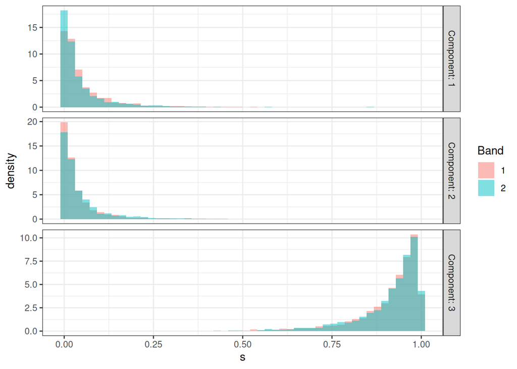

```r
plot_draw_histograms(output_draws, "s")
```

Component 3 captures most of the variance in both Band 1 (91%) and in Band 2 (91%). Components 1 and 2 capture less than 6% of the variance each.

This suggests that only Component 3’s parameter estimates should be interpreted as reliable.

## Checking $\ell$

Coherence length is $\ell = \frac{1}{\sqrt{\Sigma}}$. There cannot be a stable cross-covariance if two oscillators already drift out of phase within just one coherence length. Long coherence lengths (narrow spectral peaks) make the $\mu$ gap matter more, short coherence lengths (broad spectral peaks) make the gap matter less.

```r
ells <- as.data.frame(output_draws) |>
  dplyr::select(matches("ell"), -.draw) |>
  colMeans() |>
  matrix(ncol = 2)
ells
```

```
          [,1]     [,2]
[1,] 1.8396170 1.781973
[2,] 1.6942468 1.698985
[3,] 0.4409658 0.366069
```

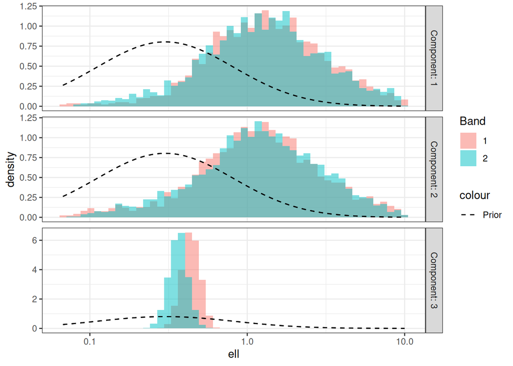

```r
plot_draw_histograms(output_draws, "ell") +
  geom_function(fun = dlnorm,
                args = list(meanlog = -0.2, sdlog = 1),
                mapping = aes(colour = "Prior"),
                linetype = "dashed") +
  scale_colour_manual(values = "black") +
  scale_x_continuous(transform = "log10",
                     labels = scales::label_number(accuracy = 0.1))
```

$\ell$ does not appear to be pushed up against any bounds or degerated to zero.

## Checking coupling between bands within components

How well the frequencies in the two bands line up within a component, i.e., a frequency overlap factor on [0,1].

Coupling = 1 suggests both bands oscillate at same frequency. Coupling = 0 means two frequency peaks do not overlap, i.e., no shared structure between bands.

```r
ds <- output$draws(c("mu", "Sigma"), format = "matrix") |> subset_draws(chain = valid_chains)

z_coupling <- function(q, d) {
  mu1 <- d[, paste0("mu[", q, ",1]")]
  mu2 <- d[, paste0("mu[", q, ",2]")]
  S1  <- d[, paste0("Sigma[", q, ",1]")]
  S2  <- d[, paste0("Sigma[", q, ",2]")]
  z <- abs(mu1 - mu2) / (2 * sqrt(S1 + S2))
  exp(-z^2) # peak coupling between the two bands
}

coup <- sapply(1:3, function(q) quantile(z_coupling(q, ds), c(0.05, 0.5, 0.95)))
colnames(coup) <- paste("Component", 1:3)
round(coup, 2)
```

```
    Component 1 Component 2 Component 3
5%         0.10        0.15        0.98
50%        0.94        0.93        1.00
95%        1.00        1.00        1.00
```

Component 3 has a tightly shared oscillation between the bands, i.e., Bands 1 and Band 2 in Component 3 have close enough oscillation frequencies to remain correlated.

## Interpreting `signal_sd`

$S_i$ is the total standard deviation of the signal in each band, here: $i = 1,2$.

```r
signal_sds <- as.data.frame(output_draws) |>
  dplyr::select(matches("signal_sd"), -.draw) |>
  colMeans()
signal_sds
```

```
signal_sd[1] signal_sd[2]
   0.8636997    0.8846399
```

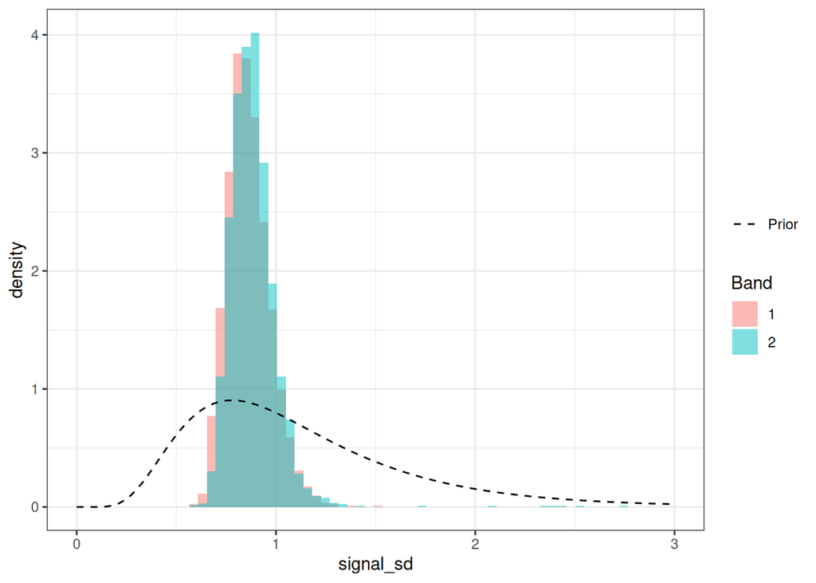

```r
output_draws |>
  as.data.frame() |>
  dplyr::select(.draw, starts_with("signal")) |>
  pivot_longer(2:3) |>
  separate_wider_position(cols = name,  width = c("p" = 9, 1, "Band" = 1, 1)) |>
  ggplot() +
  geom_histogram(mapping = aes(x = value, fill = Band, y = after_stat(density)),
                 bins = 50,
                 position = "identity",
                 alpha = 0.5) +
  geom_function(fun = dlnorm,
                args = list(sdlog = 0.5),
                mapping = aes(colour = "Prior"),
                linetype = "dashed",
                xlim = c(0, 3)) +
  scale_colour_manual(values = "black") +
  labs(x = "signal_sd", colour = "")
```

Recalling that the response variable $y$ has been standardised, we expect the total standard deviation of each band to be close to 1, which it is.

## Interpreting $\Sigma$

$\Sigma$s refer to the widths of the bumps in the spectral domain centred at the $\mu$s.

```r
input_params$Sigma
```

```
     [,1] [,2]
[1,]    4    4
[2,]    4    4
[3,]    4    4
```

```r
Sigmas <- as.data.frame(output_draws) |>
  dplyr::select(matches("Sigma")) |>
  summarise(across(everything(), mean)) |>
  matrix(ncol = 2)
Sigmas
```

```
     [,1]     [,2]
[1,] 3.125502 3.369367
[2,] 4.680353 3.795772
[3,] 5.413435 7.894322
```

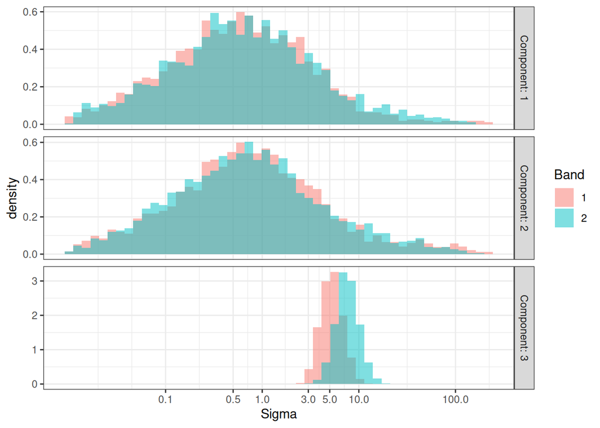

```r
plot_draw_histograms(output_draws, "Sigma") +
  scale_x_continuous(transform = "log10",
                     breaks = c(0.1, 0.5, 1, 3, 5, 10, 100),
                     labels = scales::label_number(accuracy = 0.1))
```

## Interpreting $w$ and $v$

$w$ is the *amplitude* of the spectral component $q$ in band $i$ (standardised units).

```r
input_params$w
```

```
     [,1] [,2]
[1,]    1    1
[2,]    1    1
[3,]    1    1
```

```r
ws <- as.data.frame(output_draws) |>
  dplyr::select(matches("w"), -.draw) |>
  colMeans() |>
  matrix(ncol = 2)
ws
```

```
          [,1]      [,2]
[1,] 0.1396136 0.1351387
[2,] 0.1098827 0.1245827
[3,] 0.3438646 0.3201959
```

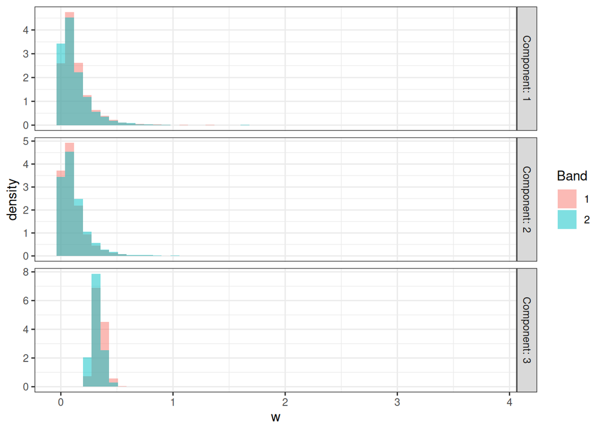

```r
plot_draw_histograms(output_draws, "w")
```

If $w$ is near zero, then $\theta$ and $\phi$ for that component revert to their priors.

It is perhaps easier to interpret the kernel (amplitude) variance in the time domain, instead of the (amplitude) magnitude in the spectral domain. Indeed, in this model, $w$ is a derived quantity from $v$.

```r
vs <- as.data.frame(output_draws) |>
  dplyr::select(matches("v"), -.draw) |>
  colMeans() |>
  matrix(ncol = 2)
vs
```

```
           [,1]       [,2]
[1,] 0.04169971 0.04841068
[2,] 0.03022467 0.03757731
[3,] 0.68559539 0.71235174
```

$v(q,i)$ is the amount of variance contributed by component $q$ to band $i$.

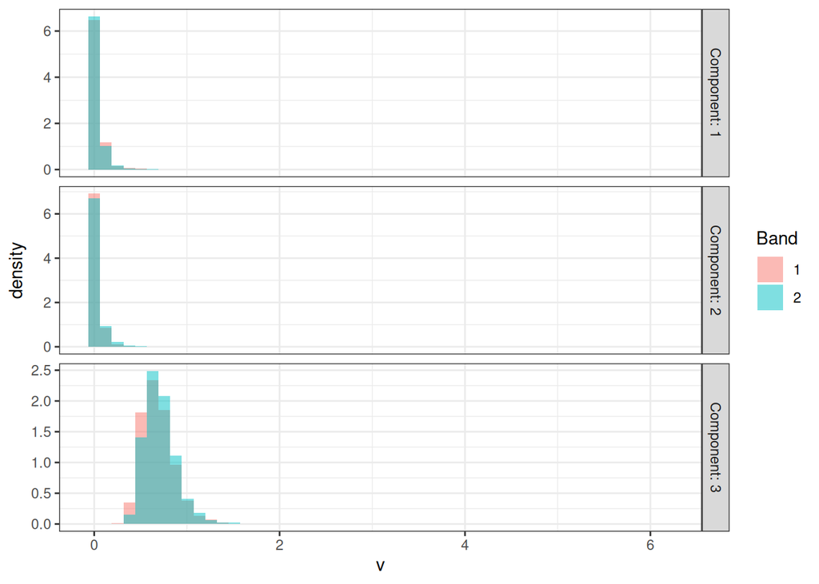

```r
plot_draw_histograms(output_draws, "v")
```

Component 3 contributes the most in both Bands 1 and 2.

## Interpreting $\mu$s

```r
input_params$mu
```

```
     [,1] [,2]
[1,]    1    1
[2,]    2    2
[3,]    5    6
```

```r
mus <- as.data.frame(output_draws) |>
  dplyr::select(matches("mu"), -.draw) |>
  colMeans() |>
  matrix(ncol = 2)
mus
```

```
          [,1]     [,2]
[1,] 0.6497476 1.395767
[2,] 1.5323411 1.449869
[3,] 2.9429853 3.447826
```

Each cell `mu[q, i]` indicates the dominant oscillation frequency (radians/unit time) of the q-th (row) component in the i-th (column) band.

When each $\mu$ differs between bands (within a component), the cross-covariance has an oscillation frequency that is the variance weighted average of the two, i.e., $\mu_{ij}$ is frequency of the product of two Gaussians; pulled towards the one with the narrower peak.

As the $\mu$s become more separated within a component, the component is really just two unrelated oscillators. In such cases, $\theta$ and $\phi$ are no longer meaningful and just reflect their priors.

If cross-covariance is zero, then there’s insufficient information to estimate $\theta$ or $\phi$. $\mu$s are still identifiable but this component is really two unrelated oscillators, i.e., there is no shared signal to be delayed between bands.

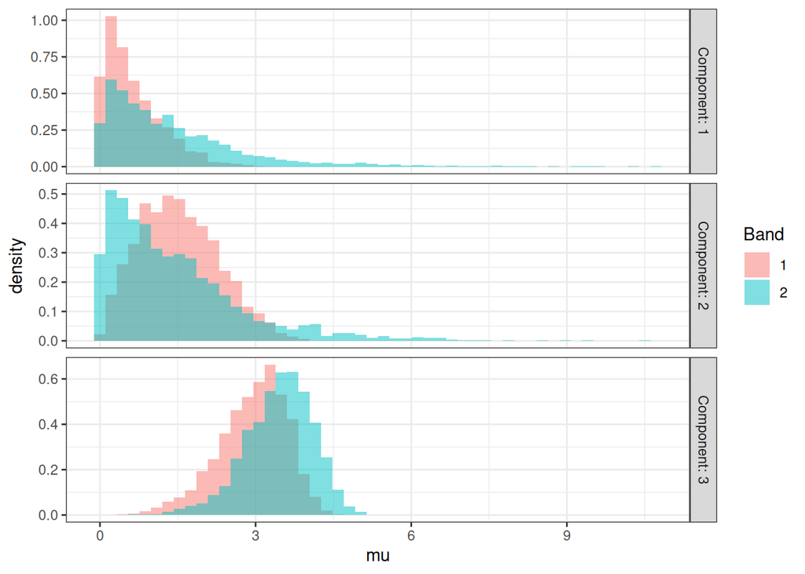

```r
plot_draw_histograms(output_draws, "mu")
```

Only Component 3 is interpretable given the neglible $s$s in the other Components.

## Interpreting $\theta$s

Entry `theta[q,i]` is band `i`’s (column) time shift within component `q` (row).

The delay between bands 1 and 2 in component `q` is `theta[q, 1] − theta[q, 2]`.

A delay is only meaningful relative to how fast the cross-covariance decays.

```r
input_params$theta
```

```
     [,1] [,2]
[1,]    0  0.5
[2,]    0  0.5
[3,]    0  0.5
```

```r
thetas <- as.data.frame(output_draws) |>
  dplyr::select(matches("theta"), -.draw) |>
  colMeans() |>
  matrix(ncol = 2)
thetas
```

```
     [,1]       [,2]
[1,]    0 0.03946591
[2,]    0 0.03349197
[3,]    0 0.50043479
```

The element `theta[3,2]` = 0.5, means that in component 3, the time shift between band 2 and band 1 is 0.5. Alternatively, component 3 in band 1 at time $t$ lines up with band 2 at $t - 0.5$.

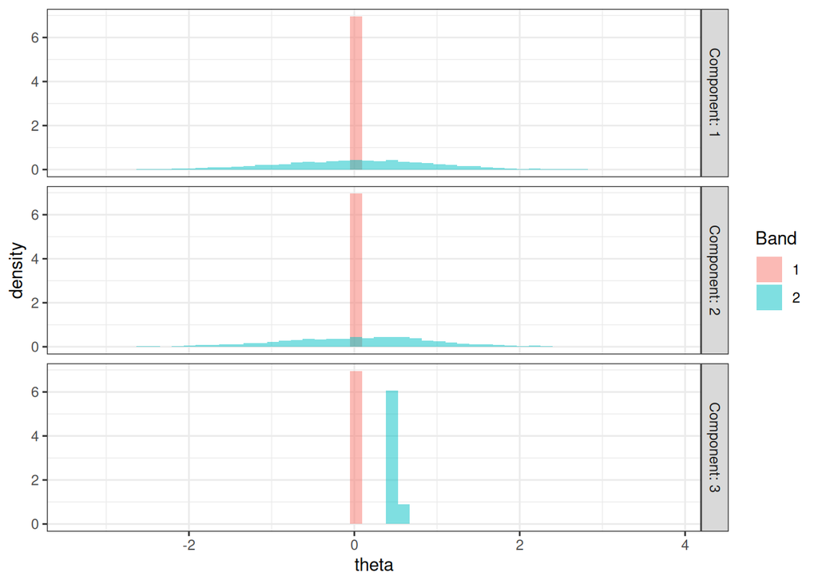

```r
plot_draw_histograms(output_draws, "theta")
```

Only Component 3 has a distinct lag between bands.

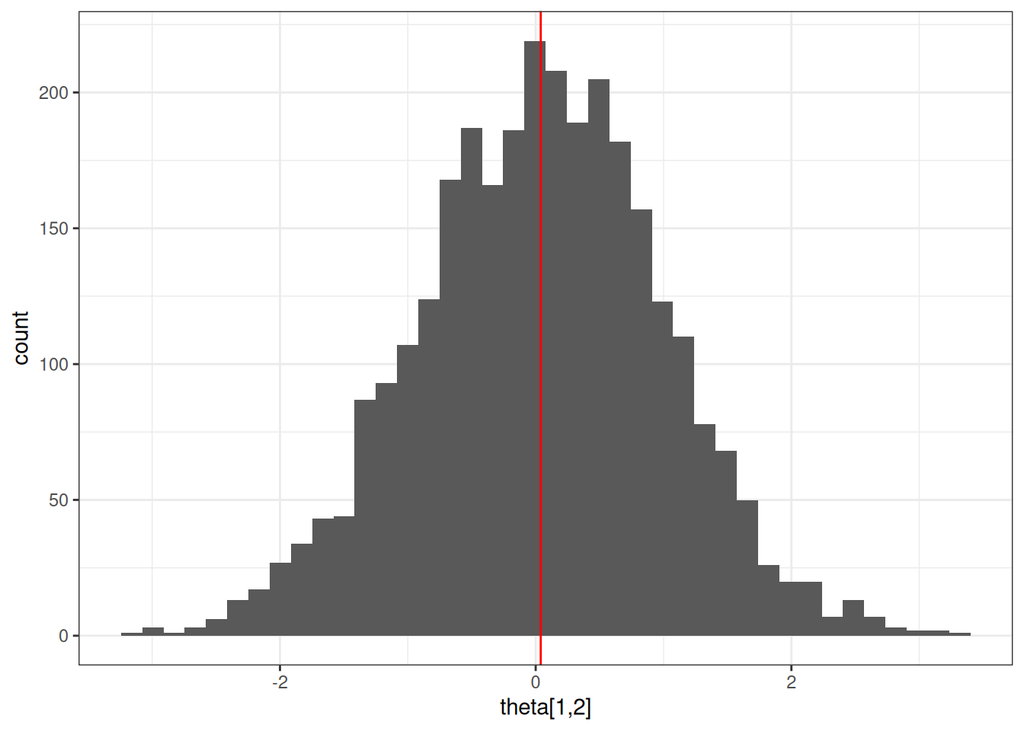

```r
output_draws |>
  ggplot() +
  aes(x = `theta[1,2]`) +
  geom_histogram(bins = 40) +
  geom_vline(xintercept = posterior_means["theta[1,2]"], colour = "red")
```

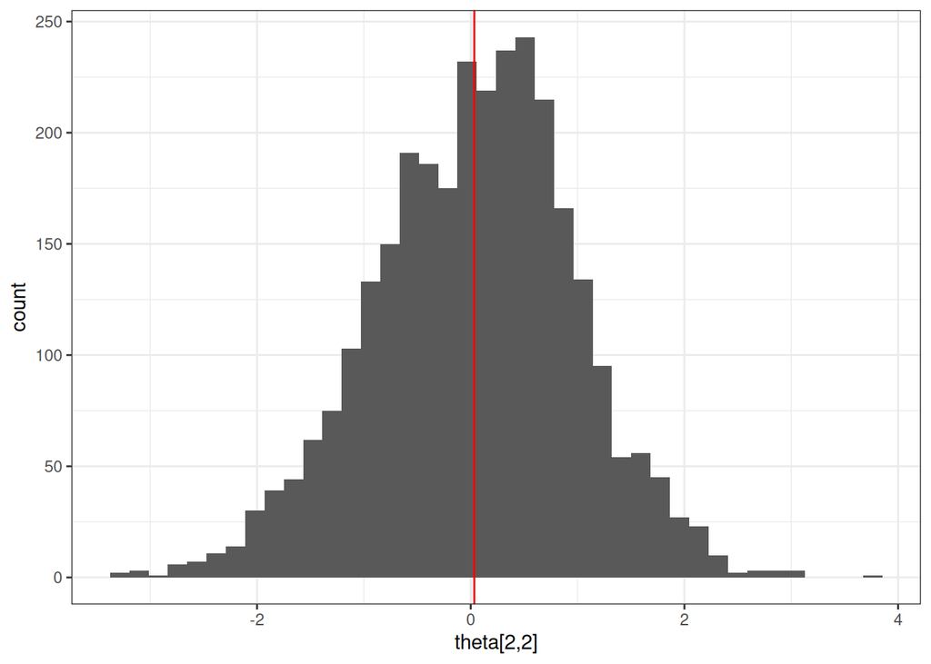

```r
output_draws |>
  ggplot() +
  aes(x = `theta[2,2]`) +
  geom_histogram(bins = 40) +
  geom_vline(xintercept = posterior_means["theta[2,2]"], colour = "red")
```

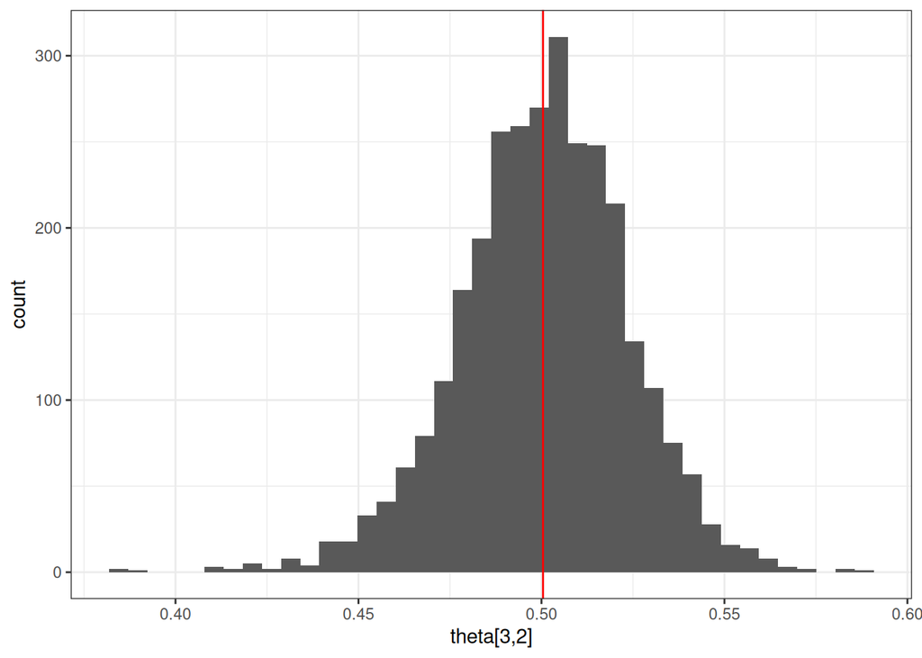

```r
output_draws |>
  ggplot() +
  aes(x = `theta[3,2]`) +
  geom_histogram(bins = 40) +
  geom_vline(xintercept = posterior_means["theta[3,2]"], colour = "red")
```

## Interpreting $\phi$s

```r
input_params$phi
```

```
     [,1] [,2]
[1,]    0    0
[2,]    0    0
[3,]    0    0
```

```r
phis <- as.data.frame(output_draws) |>
  dplyr::select(matches("phi"), -.draw) |>
  colMeans() |>
  matrix(ncol = 2)
phis
```

```
     [,1]        [,2]
[1,]    0  0.13048549
[2,]    0  0.03941036
[3,]    0 -0.04217033
```

A time shift of $\theta_{ij}$ corresponds to a phase shift of $\mu_{ij} \times \theta_{ij} + \phi_{ij}$ radians, i.e., the net phase offset at that frequency.

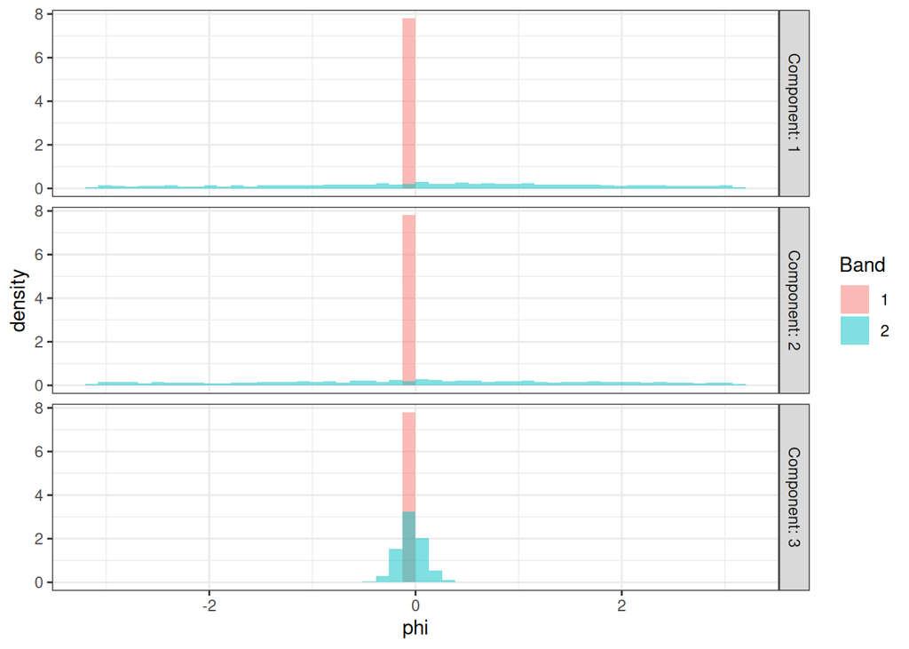

```r
plot_draw_histograms(output_draws, "phi")
```

The $\phi$s are indistinguishable from zero.